# DP_HW2

Maha Siva

2026-09-21

```r
library(readr)

x <- read_csv("image1.csv")
## Convert data frame into a matrix
x <- data.matrix(x)
```

## Image 1

```r
pca_rank_k_approx <- function(X, k) {

  pca <- prcomp(
    X,
    center = FALSE,
    scale. = FALSE
  )

  Z <- pca$x
  U <- pca$rotation

  Zk <- Z[, 1:k, drop = FALSE]
  Uk <- U[, 1:k, drop = FALSE]

  Xk <- Zk %*% t(Uk)

  error <- norm(X - Xk, type = "F")

  list(
    approx = Xk,
    error = error,
    U = U,
    Z = Z
  )
}
```

### Part 2

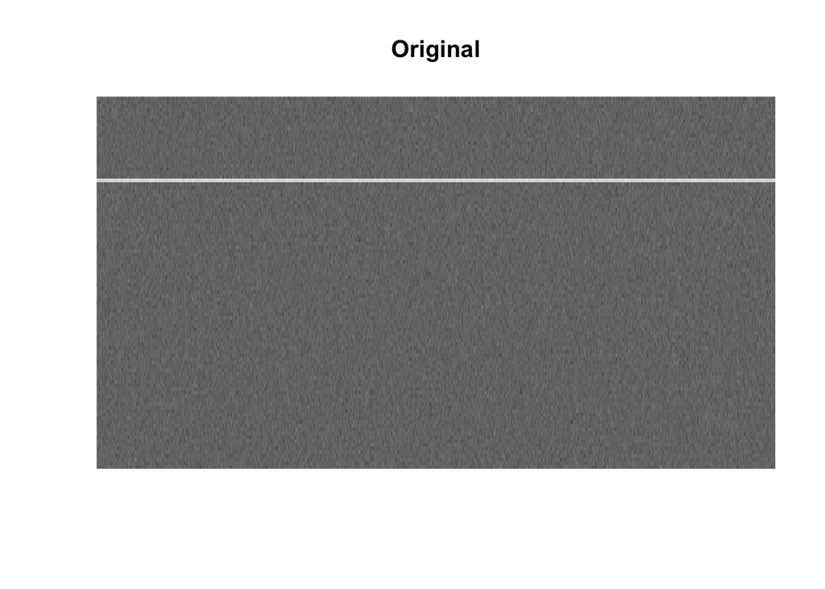

```r
# Original image
image(
  x,
  col = gray.colors(256),
  main = "Original",
  axes = FALSE
)
```

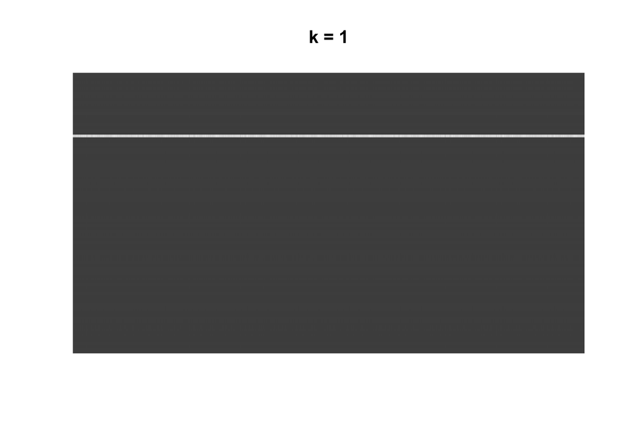

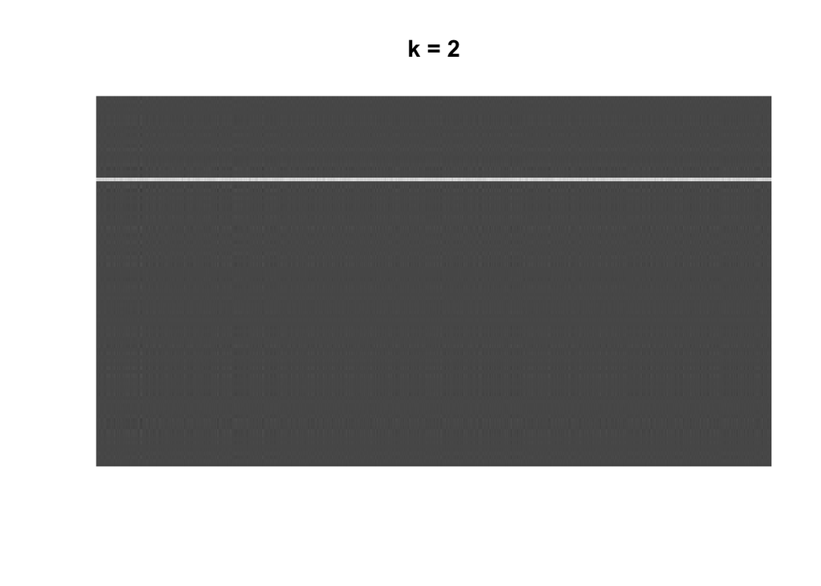

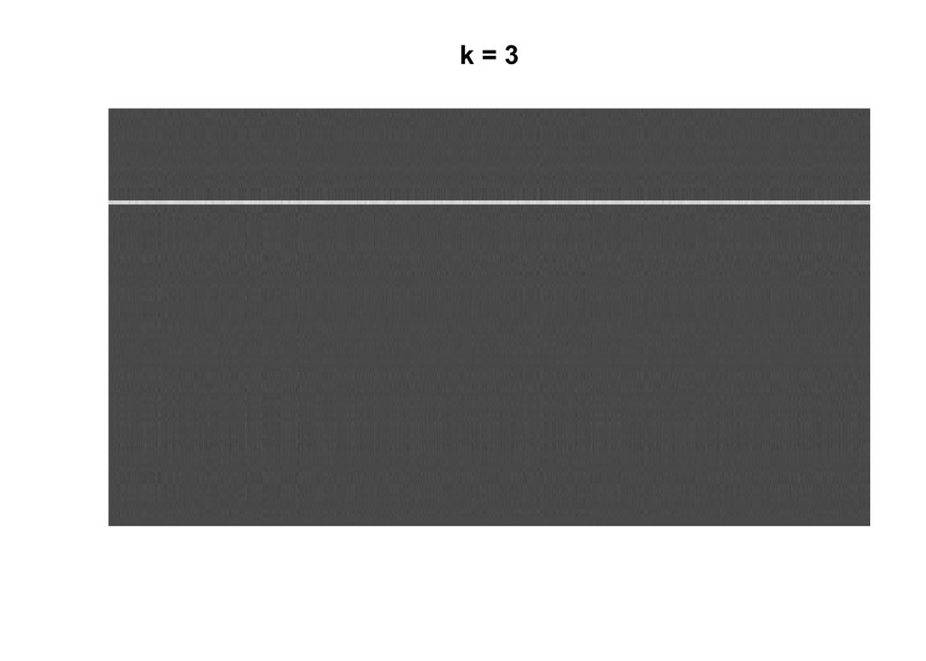

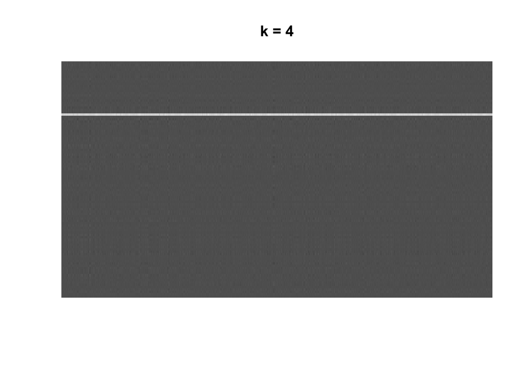

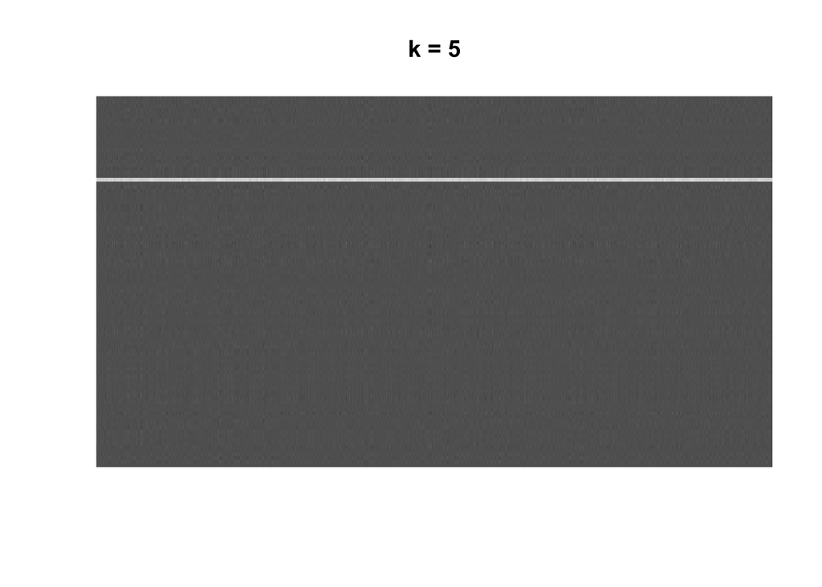

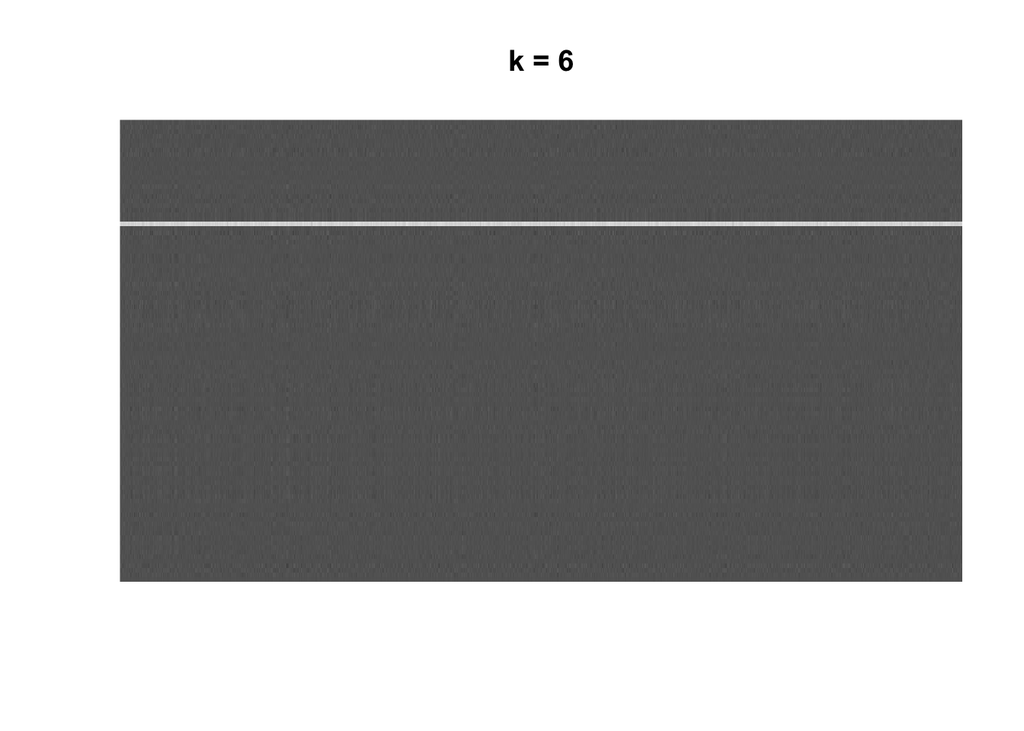

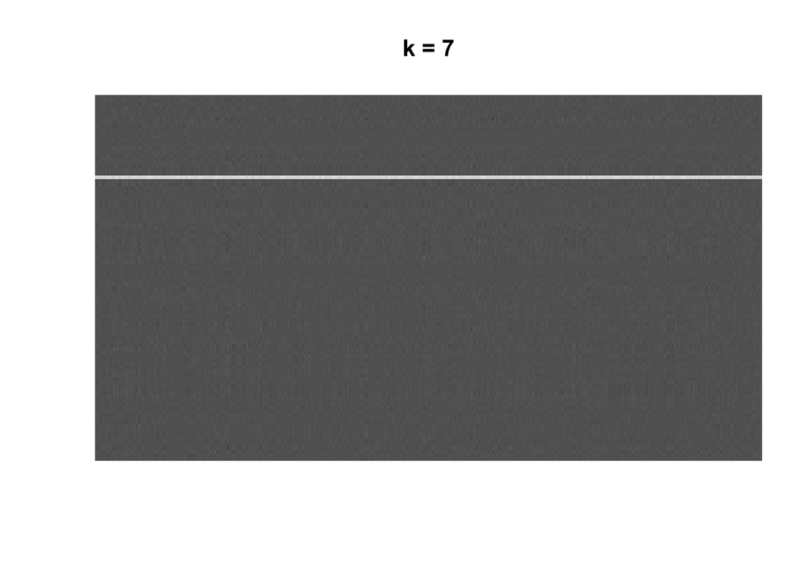

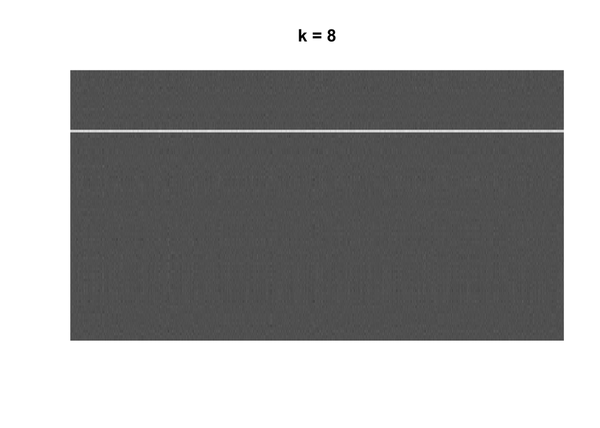

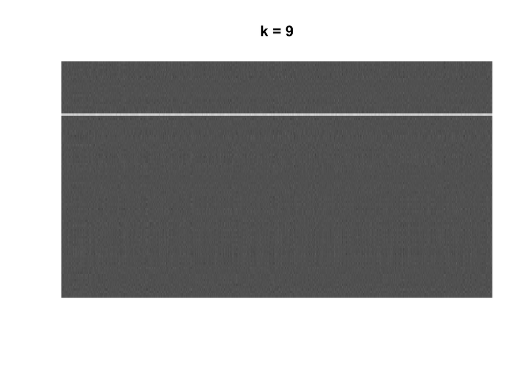

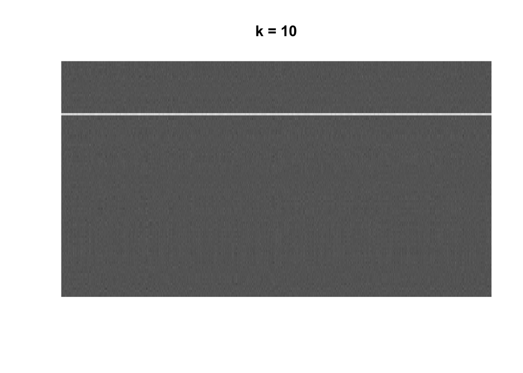

```r
# PCA approximations k = 1 through 10
for (k in 1:10) {

  result <- pca_rank_k_approx(x, k)

  image(
    result$approx,
    col = gray.colors(256),
    main = paste("k =", k),
    axes = FALSE
  )
}
```

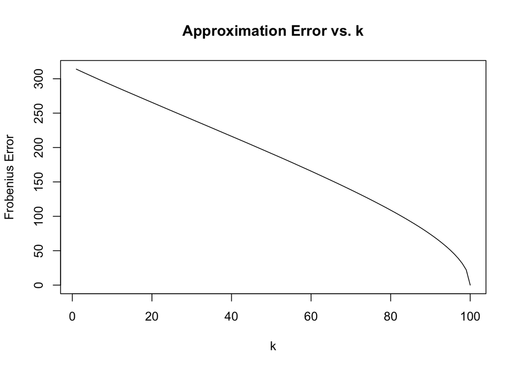

```r
### Approximation Error
p <- ncol(x)

errors <- numeric(p)

for (k in 1:p) {
  result <- pca_rank_k_approx(x, k)
  errors[k] <- result$error
}

plot(
  1:p,
  errors,
  type = "l",
  xlab = "k",
  ylab = "Frobenius Error",
  main = "Approximation Error vs. k"
)
```

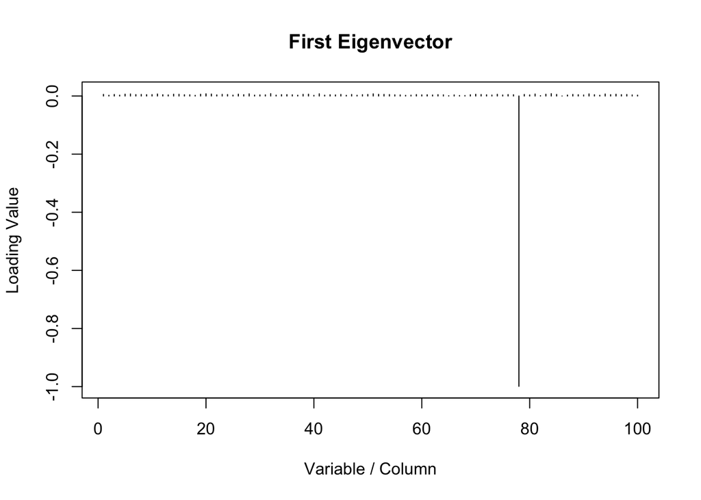

```r
## First Eigenvector and First PC score
pca <- prcomp( x,
  center = FALSE,
  scale. = FALSE
)


u1 <- pca$rotation[, 1]
z1 <- pca$x[, 1]

plot(
  u1,
  type = "h",
  main = "First Eigenvector",
  xlab = "Variable / Column",
  ylab = "Loading Value"
)
```

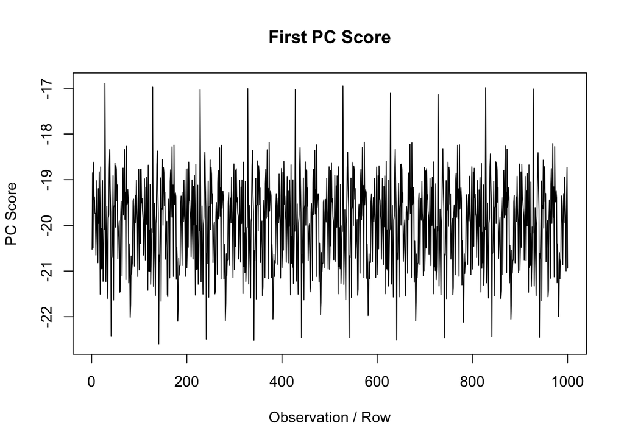

```r
plot(
  z1,
  type = "l",
  main = "First PC Score",
  xlab = "Observation / Row",
  ylab = "PC Score"
)
```

## Interpretation for Image 1

The first eigenvector is dominated by a very large loading around column 78, while the loadings for nearly all other columns are close to zero. This indicates that the first principal component is primarily capturing a feature concentrated around this column, while the remaining columns contribute relatively little to the dominant pattern. The first PC scores also remain relatively consisten across the rows, most values being concentrated around -20 and larger deviations. This suggests that the dominant pattern identified by the first eigenvector is present fairly consistently throughout the rows of the image, although its strength varies somewhat from row to row.

For Image 1, I think k=10 provides a good approximation. The rank-10 image visually preserves the main structure of the original, even though the Frobenius error continues to decrease at larger values of k.

## image 2

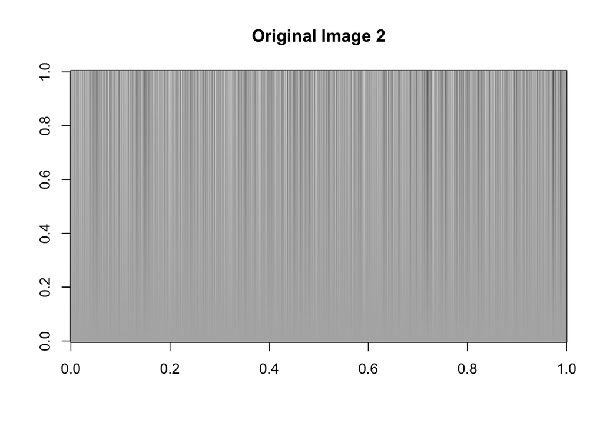

```r
# Original image


x2 <- read_csv("image2.csv")
## Convert data frame into a matrix
x2 <- data.matrix(x2)



image(
  x2,
  col = gray.colors(256),
  main = "Original Image 2"
)
```

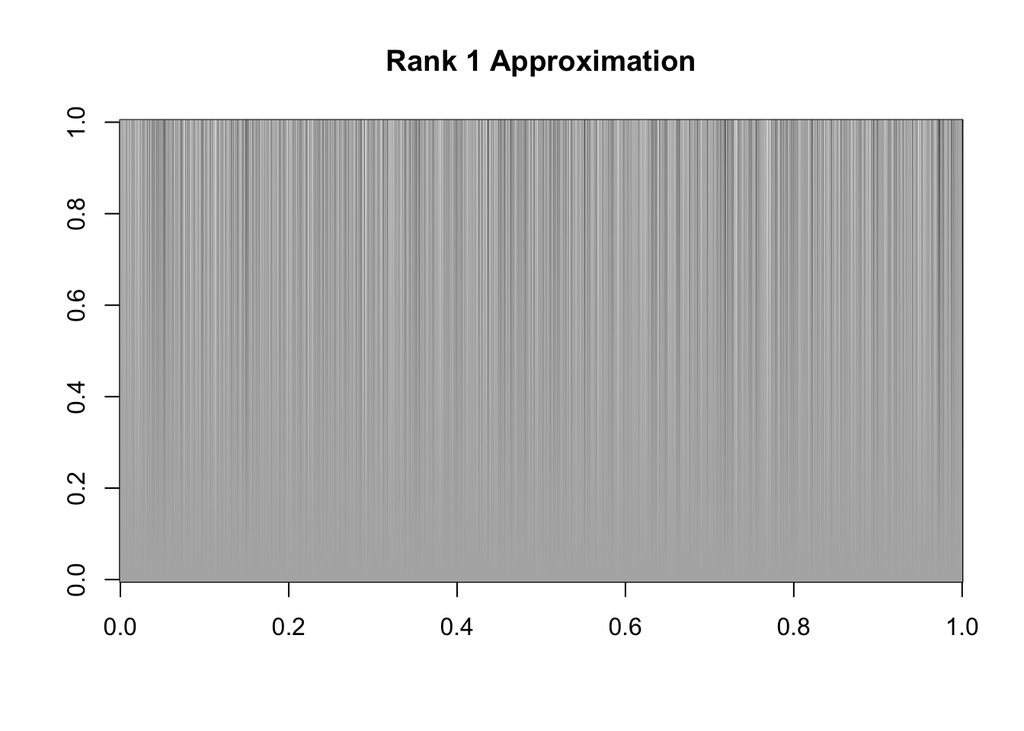

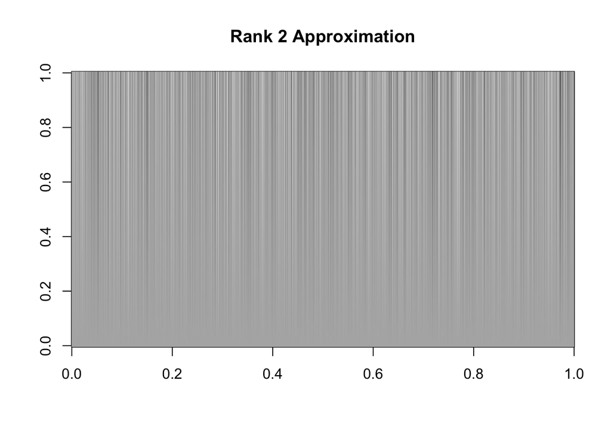

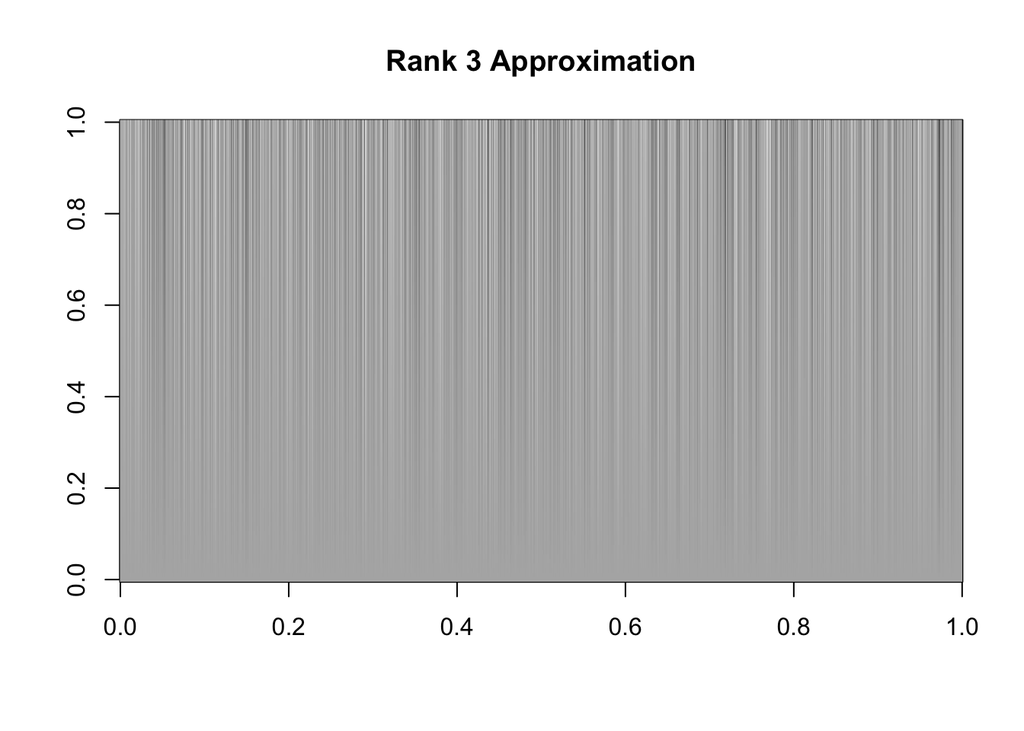

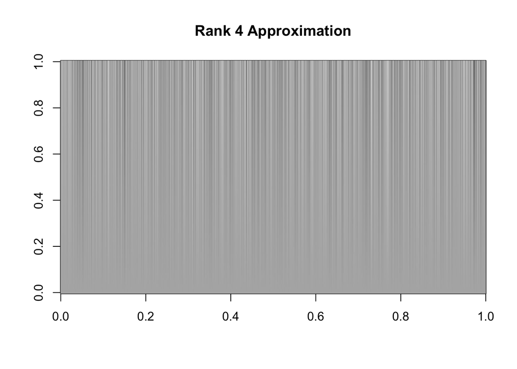

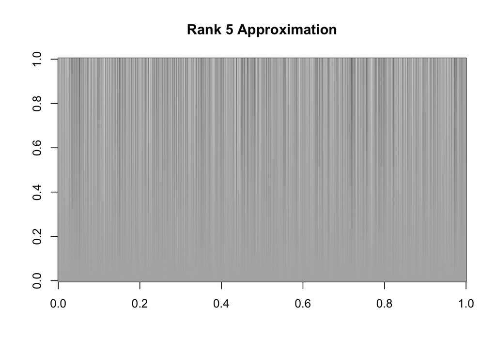

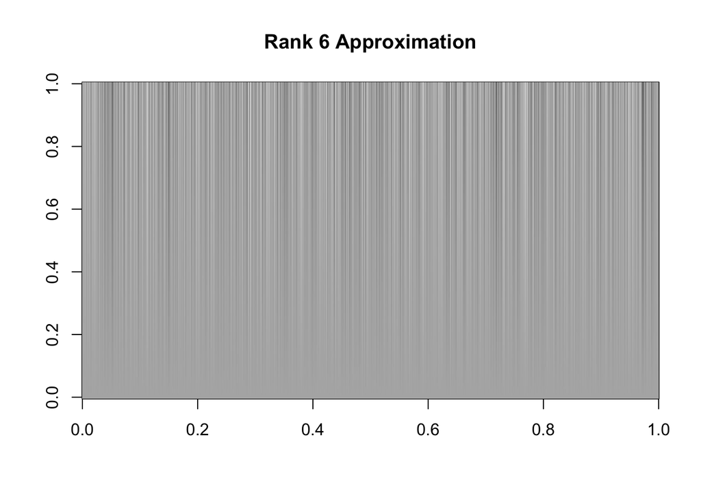

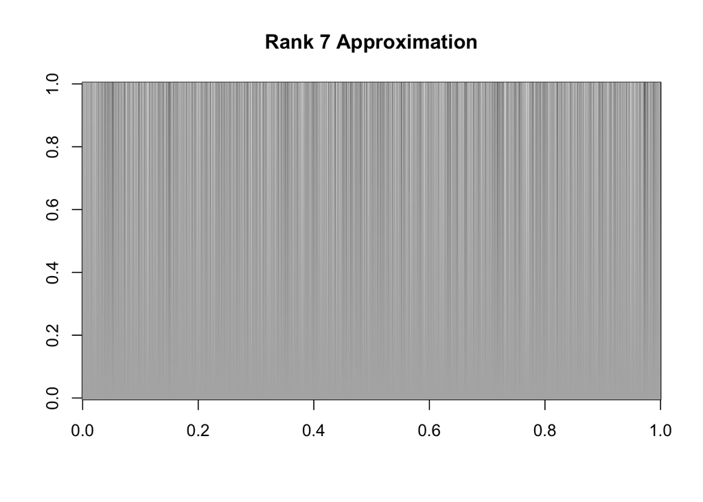

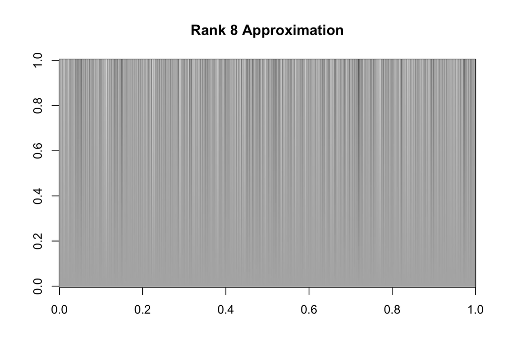

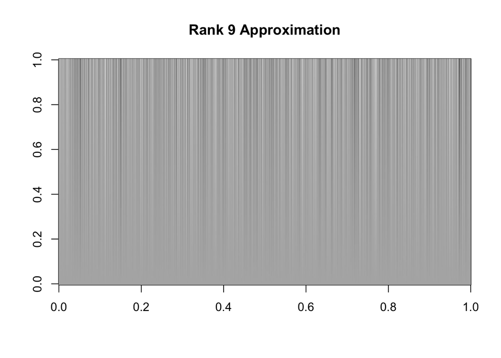

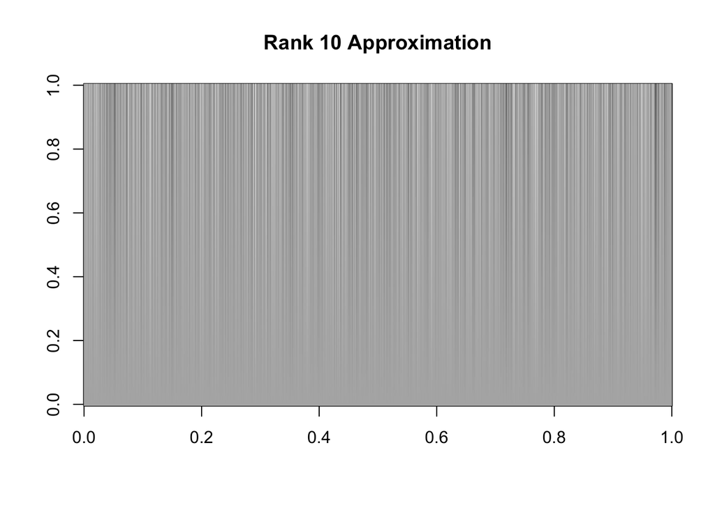

```r
# First 10 PCA approximations
for (k in 1:10) {
  result <- pca_rank_k_approx(x2, k)

  image(
    result$approx,
    col = gray.colors(256),
    main = paste("Rank", k, "Approximation")
  )
}
```

## im2 approx error

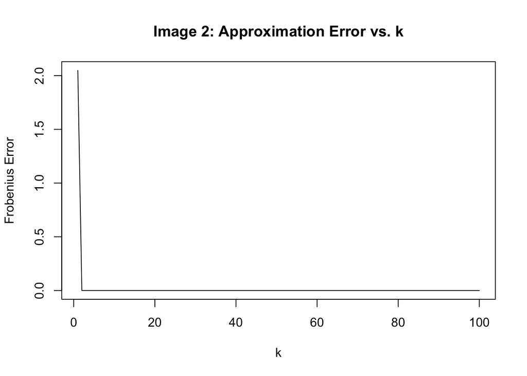

```r
p2 <- ncol(x2)
errors2 <- numeric(p2)

for (k in 1:p2) {
  result <- pca_rank_k_approx(x2, k)
  errors2[k] <- result$error
}

plot(
  1:p2,
  errors2,
  type = "l",
  xlab = "k",
  ylab = "Frobenius Error",
  main = "Image 2: Approximation Error vs. k"
)
```

## Im2, first eigenvector and PC score

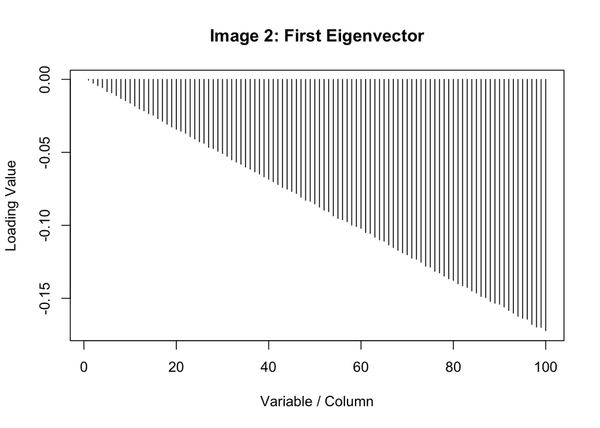

```r
pca2 <- prcomp(x2,
  center = FALSE,
  scale. = FALSE
)

u1_2 <- pca2$rotation[, 1]
z1_2 <- pca2$x[, 1]

plot(
  u1_2,
  type = "h",
  main = "Image 2: First Eigenvector",
  xlab = "Variable / Column",
  ylab = "Loading Value"
)
```

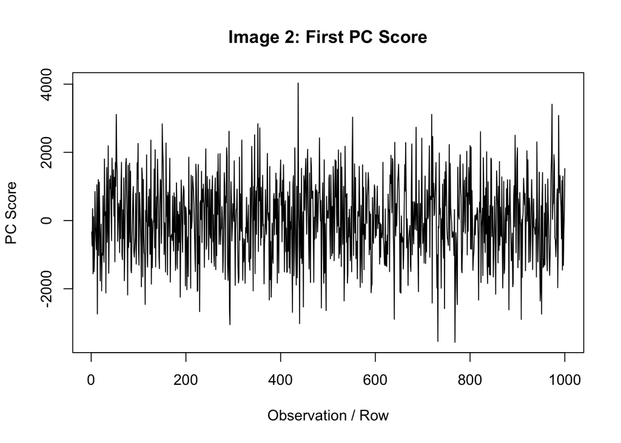

```r
plot(
  z1_2,
  type = "l",
  main = "Image 2: First PC Score",
  xlab = "Observation / Row",
  ylab = "PC Score"
)
```

## analysis:

The first eigenvector shows a clear downward pattern across the columns, indicating that the contribution of the columns to the first principal component changes systematically across the image. The first PC scores fluctuate around zero, showing that the strength and direction of this dominant pattern varies across the rows of the image.

I think k=2 provides a good approximation for Image 2. The matrix has rank 2, so two principal components are enough to reconstruct the image almost exactly. The Frobenius error after k=2 is essentially zero.

# image 3

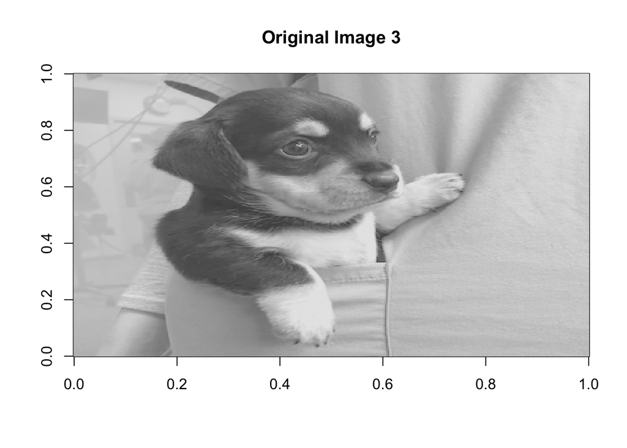

```r
x3 <- read_csv("image3.csv")
x3 <- data.matrix(x3)

image(
  x3,
  col = gray.colors(256),
  main = "Original Image 3"
)
```